# fixest包简介

陈普

2022-10-20

## 1.基本的用法

使用`fixest`包进行固定效应。为说明用法，先看一个包含了多个固定效应的数据集。

```r
library(fixest)
data("trade")
head(trade)
```

```
#>   Destination Origin Product Year  dist_km    Euros
#> 1          LU     BE       1 2007 139.5719  2966697
#> 2          BE     LU       1 2007 139.5719  6755030
#> 3          LU     BE       2 2007 139.5719 57078782
#> 4          BE     LU       2 2007 139.5719  7117406
#> 5          LU     BE       3 2007 139.5719 17379821
#> 6          BE     LU       3 2007 139.5719  2622254
```

现在考虑如下回归，

$$\ln Euros_{i,j,p,t} = \beta\cdot \ln dist_{ij} +
\gamma_i^{des}+\gamma_j^{ori}+\gamma_p^{pro}+\gamma_t^{year}+\varepsilon_{i,j,p,t}$$

包含了四个固定效应，每个固定效应下面都包含有多个“水平”。该模型估计语法如下，

```r
graols <- feols(log(Euros)~log(dist_km)|Origin+Destination+Product+Year, trade)
summary(graols)
```

```
#> OLS estimation, Dep. Var.: log(Euros)
#> Observations: 38,325
#> Fixed-effects: Origin: 15,  Destination: 15,  Product: 20,  Year: 10
#> Standard-errors: Clustered (Origin)
#>              Estimate Std. Error  t value   Pr(>|t|)
#> log(dist_km) -2.16988   0.154283 -14.0642 1.1898e-09 ***
#> ---
#> Signif. codes:  0 '***' 0.001 '**' 0.01 '*' 0.05 '.' 0.1 ' ' 1
#> RMSE: 1.74337     Adj. R2: 0.705139
#>                 Within R2: 0.219322
```

从中可以看到，

- 每个固定效应包含的“水平”，比如Origin有15个。
- 模型默认在第一个固定效应上进行聚类标准准误估计。

聚类标准误可以更加多样的形式进行控制，比如利用`summary`函数的参数`vcov`，

```r
summary(graols, vcov = 'twoway')
```

```
#> OLS estimation, Dep. Var.: log(Euros)
#> Observations: 38,325
#> Fixed-effects: Origin: 15,  Destination: 15,  Product: 20,  Year: 10
#> Standard-errors: Clustered (Origin & Destination)
#>              Estimate Std. Error  t value   Pr(>|t|)
#> log(dist_km) -2.16988   0.171367 -12.6621 4.6802e-09 ***
#> ---
#> Signif. codes:  0 '***' 0.001 '**' 0.01 '*' 0.05 '.' 0.1 ' ' 1
#> RMSE: 1.74337     Adj. R2: 0.705139
#>                 Within R2: 0.219322
```

这就是对前面两个固定效应进行聚类标准误估计。你也可以在第三个固定效应上进行聚类，如

```r
summary(graols, vcov = ~ Product)
```

```
#> OLS estimation, Dep. Var.: log(Euros)
#> Observations: 38,325
#> Fixed-effects: Origin: 15,  Destination: 15,  Product: 20,  Year: 10
#> Standard-errors: Clustered (Product)
#>              Estimate Std. Error t value  Pr(>|t|)
#> log(dist_km) -2.16988   0.077077 -28.152 < 2.2e-16 ***
#> ---
#> Signif. codes:  0 '***' 0.001 '**' 0.01 '*' 0.05 '.' 0.1 ' ' 1
#> RMSE: 1.74337     Adj. R2: 0.705139
#>                 Within R2: 0.219322
```

```r
# summary(graols, cluster = "Product") # 效果一致
# summary(graols, cluster = ~Product)
```

或者在三个维度上聚类，

```r
summary(graols, vcov = ~ Origin + Destination + Product)
```

```
#> OLS estimation, Dep. Var.: log(Euros)
#> Observations: 38,325
#> Fixed-effects: Origin: 15,  Destination: 15,  Product: 20,  Year: 10
#> Standard-errors: Clustered (Origin & Destination & Product)
#>              Estimate Std. Error  t value   Pr(>|t|)
#> log(dist_km) -2.16988   0.174865 -12.4089 6.0767e-09 ***
#> ---
#> Signif. codes:  0 '***' 0.001 '**' 0.01 '*' 0.05 '.' 0.1 ' ' 1
#> RMSE: 1.74337     Adj. R2: 0.705139
#>                 Within R2: 0.219322
```

或者不聚类，

```r
summary(graols, vcov = 'iid')
```

```
#> OLS estimation, Dep. Var.: log(Euros)
#> Observations: 38,325
#> Fixed-effects: Origin: 15,  Destination: 15,  Product: 20,  Year: 10
#> Standard-errors: IID
#>              Estimate Std. Error  t value  Pr(>|t|)
#> log(dist_km) -2.16988   0.020928 -103.685 < 2.2e-16 ***
#> ---
#> Signif. codes:  0 '***' 0.001 '**' 0.01 '*' 0.05 '.' 0.1 ' ' 1
#> RMSE: 1.74337     Adj. R2: 0.705139
#>                 Within R2: 0.219322
```

## 2.抽取固定效应系数

也能获得固定效应的系数，

```r
fixeff <- fixef(graols)
summary(fixeff)
```

```
#> Fixed_effects coefficients
#>                         Origin Destination Product  Year
#> Number of fixed-effects     15          15      20    10
#> Number of references         0           1       1     1
#> Mean                      24.1         4.3    1.26 0.172
#> Standard-deviation        1.84        1.48    1.57 0.134
#>
#> COEFFICIENTS:
#>   Origin:    AT    BE    DE    DK    ES
#>           22.69 24.81 26.33 24.13 25.84 ... 10 remaining
#> -----
#>   Destination:    AT    BE    DE    DK    ES
#>                3.151 4.027 5.795 3.959 5.811 ... 10 remaining
#> -----
#>   Product: 1     2     3     4        5
#>            0 2.844 2.201 3.302 -0.01484 ... 15 remaining
#> -----
#>   Year: 2007    2008    2009    2010   2011
#>            0 0.07033 0.02979 0.06202 0.1749 ... 5 remaining
```

绘图看固定效应系数的走势，

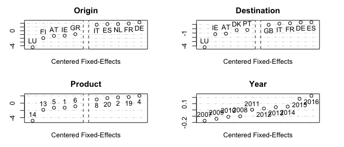

```r
plot(fixeff)
```

## 3.交互固定效应

两个原因可能想做交互固定效应。一是简单看看两个固定效应的联合,比如$firm\times country$。二是考虑可变斜率，比如在DID中经常提到的个体的时间趋势。下面的代码分别演示两种目的。

先构造一个数据集，

```r
base = iris
names(base) = c("y", paste0("x", 1:3), "fe1")
# Create another "fixed-effect"
base$fe2 = rep(letters[1:5], 30)
head(base)
```

```
#>     y  x1  x2  x3    fe1 fe2
#> 1 5.1 3.5 1.4 0.2 setosa   a
#> 2 4.9 3.0 1.4 0.2 setosa   b
#> 3 4.7 3.2 1.3 0.2 setosa   c
#> 4 4.6 3.1 1.5 0.2 setosa   d
#> 5 5.0 3.6 1.4 0.2 setosa   e
#> 6 5.4 3.9 1.7 0.4 setosa   a
```

交互固定效应，

```r
est_comb = feols(y ~ x1 | fe1^fe2, base)
est_comb
```

```
#> OLS estimation, Dep. Var.: y
#> Observations: 150
#> Fixed-effects: fe1^fe2: 15
#> Standard-errors: Clustered (fe1^fe2)
#>    Estimate Std. Error t value   Pr(>|t|)
#> x1 0.782815   0.119465 6.55267 1.2854e-05 ***
#> ---
#> Signif. codes:  0 '***' 0.001 '**' 0.01 '*' 0.05 '.' 0.1 ' ' 1
#> RMSE: 0.406785     Adj. R2: 0.729861
#>                  Within R2: 0.280234
```

```r
fixef(est_comb)[[1]] # 抽取固定效应系数
```

```
#>     setosa_a     setosa_b     setosa_c     setosa_d     setosa_e versicolor_a
#>     2.443630     2.384084     2.164943     2.296256     2.323630     3.713320
#> versicolor_b versicolor_c versicolor_d versicolor_e  virginica_a  virginica_b
#>     3.800694     4.003367     3.745539     3.575086     4.513272     3.986351
#>  virginica_c  virginica_d  virginica_e
#>     4.423725     4.216804     4.159382
```

现在想做一个回归，$y$对$x1,x2$回归，但是$x2$的系数随着固定效应$fe1$而变，那么可如下进行，

```r
est_vs = feols(y ~ x1 | fe1[x2], base)
est_vs
```

```
#> OLS estimation, Dep. Var.: y
#> Observations: 150
#> Fixed-effects: fe1: 3
#> Varying slopes: x2 (fe1: 3)
#> Standard-errors: Clustered (fe1)
#>    Estimate Std. Error t value Pr(>|t|)
#> x1 0.450006   0.156731  2.8712  0.10292
#> ---
#> Signif. codes:  0 '***' 0.001 '**' 0.01 '*' 0.05 '.' 0.1 ' ' 1
#> RMSE: 0.298706     Adj. R2: 0.863506
#>                  Within R2: 0.178944
```

```r
summary(fixef(est_vs)) # 看x2的斜率系数
```

```
#> Fixed-effects/Slope coefficients
#>                                 fe1 x2 (slopes: fe1)
#> Number of fixed-effects/slopes    3                3
#> Number of references              0                0
#> Mean                            1.7            0.639
#> Standard-deviation             1.32            0.262
#>
#> COEFFICIENTS:
#>   fe1: setosa versicolor virginica
#>         2.926      1.879    0.3068
#> -----
#>   x2 (slopes: fe1): setosa versicolor virginica
#>                     0.3677     0.6598    0.8903
```

## 4.因子变量的用法

因子变量可在公式中以`i()`形式引入，该函数包含两个参数`ref`和`keep`，分别用来指定基准组和要保留的组。

```r
data(airquality)
res_i1 = feols(Ozone ~ Solar.R + i(Month), airquality)
res_i2 = feols(Ozone ~ Solar.R + i(Month, ref = 8), airquality)
res_i3 = feols(Ozone ~ Solar.R + i(Month, keep = 5:6), airquality)

etable(res_i1, res_i2, res_i3, dict = c("6" = "June", "Month::5" = "May"),
       order = c("Int|May", "Mon"))
```

```
#>                             res_i1             res_i2             res_i3
#> Dependent Var.:              Ozone              Ozone              Ozone
#>
#> (Intercept)          3.219 (7.919)   40.12*** (7.828)   25.82*** (6.681)
#> May                                 -36.90*** (8.201)  -24.50*** (6.936)
#> Month = June         5.069 (10.98)   -31.83** (11.05)    -19.46. (10.46)
#> Month = 7         31.04*** (8.018)     -5.861 (8.146)
#> Month = 8         36.90*** (8.201)
#> Month = 9            8.912 (7.763)  -27.99*** (7.845)
#> Solar.R         0.1148*** (0.0300) 0.1148*** (0.0300) 0.1253*** (0.0311)
#> _______________ __________________ __________________ __________________
#> S.E. type                      IID                IID                IID
#> Observations                   111                111                111
#> R2                         0.31974            0.31974            0.22452
#> Adj. R2                    0.28735            0.28735            0.20278
#> ---
#> Signif. codes: 0 '***' 0.001 '**' 0.01 '*' 0.05 '.' 0.1 ' ' 1
```

也可以来个简单的DID估计，

```r
data(base_did)
head(base_did)
```

```
#>             y         x1 id period post treat
#> 1  2.87530627  0.5365377  1      1    0     1
#> 2  1.86065272 -3.0431894  1      2    0     1
#> 3  0.09416524  5.5768439  1      3    0     1
#> 4  3.78147485 -2.8300587  1      4    0     1
#> 5 -2.55819959 -5.0443544  1      5    0     1
#> 6  1.72873240 -0.6363849  1      6    1     1
```

```r
est_did = feols(y ~ x1 + i(period, treat, 5) | id + period, base_did) # 第5组是参考组
est_did
```

```
#> OLS estimation, Dep. Var.: y
#> Observations: 1,080
#> Fixed-effects: id: 108,  period: 10
#> Standard-errors: Clustered (id)
#>                   Estimate Std. Error   t value   Pr(>|t|)
#> x1                0.973490   0.045678 21.311868  < 2.2e-16 ***
#> period::1:treat  -1.403045   1.110267 -1.263701 2.0908e-01
#> period::2:treat  -1.247511   1.093145 -1.141213 2.5633e-01
#> period::3:treat  -0.273206   1.106935 -0.246813 8.0553e-01
#> period::4:treat  -1.795721   1.087974 -1.650518 1.0177e-01
#> period::6:treat   0.784452   1.028388  0.762798 4.4726e-01
#> period::7:treat   3.598897   1.101563  3.267081 1.4609e-03 **
#> period::8:treat   3.811766   1.247502  3.055519 2.8366e-03 **
#> period::9:treat   4.731426   1.097113  4.312617 3.6041e-05 ***
#> period::10:treat  6.606229   1.120494  5.895817 4.4031e-08 ***
#> ---
#> Signif. codes:  0 '***' 0.001 '**' 0.01 '*' 0.05 '.' 0.1 ' ' 1
#> RMSE: 3.83653     Adj. R2: 0.48783
#>                 Within R2: 0.389628
```

然后查看结果，

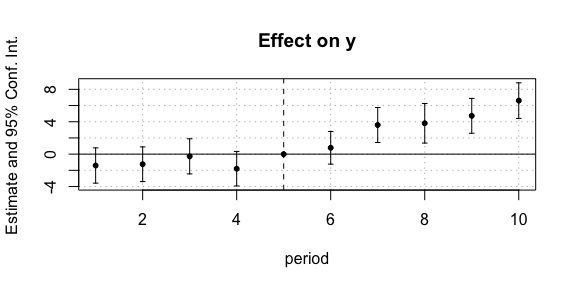

```r
iplot(est_did)
```